# Introduction to Regression with statsmodels in Python

### Predictions and odds ratios

```python
# Make predictions

mdl_recency = logit("has_churned ~ time_since_last_purchase", data=churn).fit()

explanatory_data = pd.DataFrame({"time_since_last_purchase" : np.arange(-1, 6, 0.25)})

prediction_data = explanatory_data.assign(has_churned = mdl_recency.predict(explanatory_data))
```

```
Optimization terminated successfully.
         Current function value: 0.683000
         Iterations 4
```

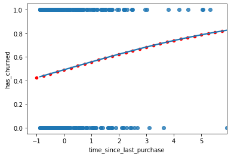

```python
# Adding point predictions

# create a regression plot
sns.regplot(x="time_since_last_purchase", y="has_churned", data=churn, ci=None, logistic=True)

# add scatter plot of predictions
sns.scatterplot(x="time_since_last_purchase", y="has_churned", data=prediction_data, color="red")

# show graph
plt.show()
```

```python
# Getting the most likely outcome
## just round the predicted probabilities, using Numpy's round() function
prediction_data = explanatory_data.assign(has_churned = mdl_recency.predict(explanatory_data))

# Add new column for rounded values
prediction_data["most_likely_outcome"] = np.round(prediction_data["has_churned"])

# preview the dataset
prediction_data.sample(10)
```

|  | time_since_last_purchase | has_churned | most_likely_outcome |
| --- | --- | --- | --- |
| 3 | -0.25 | 0.474441 | 0.0 |
| 12 | 2.00 | 0.623260 | 1.0 |
| 14 | 2.50 | 0.654305 | 1.0 |
| 8 | 1.00 | 0.558283 | 1.0 |
| 9 | 1.25 | 0.574809 | 1.0 |
| 2 | -0.50 | 0.457695 | 0.0 |
| 24 | 5.00 | 0.787690 | 1.0 |
| 17 | 3.25 | 0.698450 | 1.0 |
| 13 | 2.25 | 0.638928 | 1.0 |
| 27 | 5.75 | 0.819500 | 1.0 |

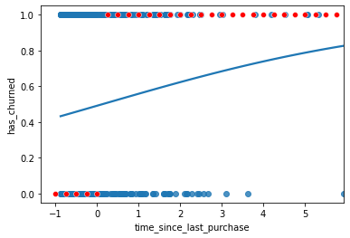

```python
# Let's visualize the most likely outcome

# create a regression plot
sns.regplot(x="time_since_last_purchase", y="has_churned", data=churn, ci=None, logistic=True)

# add scatter plot of predictions
sns.scatterplot(x="time_since_last_purchase", y="most_likely_outcome", data=prediction_data, color="red")

# show graph
plt.show()
```

### Odds ratios

The *odds ratio* is the probability of something happening, divided by the probability that it doesn't.

$ odds\_ratio = \frac{probability}{1-probability} $

For example:

$ odds\_ratio = \frac{0.25}{1-0.25} = \frac{1}{3} $

```python
# Let's compute the odds ratios and add them to the prediction data
prediction_data["odds_ratio"] = prediction_data["has_churned"] / (1 - prediction_data["has_churned"])
```

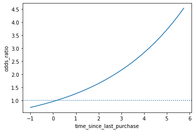

```python
# Let's visualize the odds ratio from the churn model

sns.lineplot(x="time_since_last_purchase", y="odds_ratio", data=prediction_data)

# Add a horizontal dotted line at "y = 1"
plt.axhline(y=1, linestyle="dotted")

# show plot
plt.show()
```

In the bottom left, the chances of churning are less than the chances of not churning. And vice-versa in the upper-right.

On a log-scale, odds ratios change linearly with the explanatory variable.

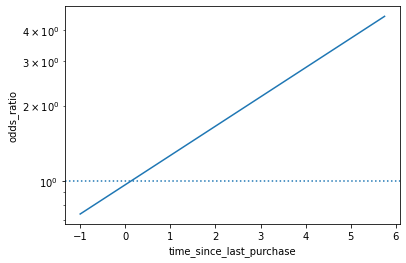

```python
# Let's visualize log odds ratios

sns.lineplot(x="time_since_last_purchase", y="odds_ratio", data=prediction_data)

# Add a horizontal dotted line at "y = 1"
plt.axhline(y=1, linestyle="dotted")

# let's change the scale of the y-axis to "log"
plt.yscale("log")

# show plot
plt.show()
```

The log odds ratio is also known as "logit".

```python
# Calculate log odds ratio
prediction_data["log_odds_ratio"] = np.log(prediction_data["odds_ratio"])

# Print prediction data
prediction_data.sample(10)
```

|  | time_since_last_purchase | has_churned | most_likely_outcome | odds_ratio | log_odds_ratio |
| --- | --- | --- | --- | --- | --- |
| 23 | 4.75 | 0.776216 | 1.0 | 3.468602 | 1.243752 |
| 21 | 4.25 | 0.751970 | 1.0 | 3.031762 | 1.109144 |
| 17 | 3.25 | 0.698450 | 1.0 | 2.316203 | 0.839929 |
| 25 | 5.25 | 0.798727 | 1.0 | 3.968384 | 1.378359 |
| 5 | 0.25 | 0.508070 | 1.0 | 1.032811 | 0.032284 |
| 8 | 1.00 | 0.558283 | 1.0 | 1.263892 | 0.234196 |
| 13 | 2.25 | 0.638928 | 1.0 | 1.769530 | 0.570714 |
| 1 | -0.75 | 0.441043 | 0.0 | 0.789046 | -0.236931 |
| 7 | 0.75 | 0.541626 | 1.0 | 1.181626 | 0.166892 |
| 11 | 1.75 | 0.607331 | 1.0 | 1.546674 | 0.436107 |

## Quantifying logistic regression fit

We'll look at confusion matrices

[figure not shown]

### Confusion matrix: counts of outcomes

A *confusion matrix (occasionally called a confusion table)* is the basis of all performance metrics for models with a categorical response (such as a logistic regression). It contains the counts of each actual response-predicted response pair. In this case, where there are two possible responses (churn or not churn), there are four overall outcomes.

1. True positive: The customer churned and the model predicted they would.
2. False positive: The customer didn't churn, but the model predicted they would.
3. True negative: The customer didn't churn and the model predicted they wouldn't.
4. False negative: The customer churned, but the model predicted they wouldn't.

```python
# Let's create the confusion matrix manually

## Let's use the "recency model" above

# get the actual responses
actual_response = churn["has_churned"]

# compute predicted responses, and round them ==> Most likely outcomes
predicted_response = np.round(mdl_recency.predict())

# create a DataFrame of "actual vs. predicted" ouctomes
outcomes = pd.DataFrame({"actual_response": actual_response, "predicted_response": predicted_response})

# print value counts of outcomes
print(outcomes.value_counts(sort=False))
```

```
actual_response  predicted_response
0                0.0                   141
                 1.0                    59
1                0.0                   111
                 1.0                    89
dtype: int64
```

We correctly predicted that 141 customers didn't churn, and 89 did churn. There were 59 false positives and 111 false negatives.

```python
# Now let's create the confusion matrix automatically

conf_matrix = mdl_recency.pred_table()
print(conf_matrix)
```

```
[[141.  59.]
 [111.  89.]]
```

```
(<Figure size 432x288 with 3 Axes>,
 {('0', '0'): (0.0, 0.0, 0.49751243781094534, 0.70265780730897),
  ('0', '1'): (0.0,
   0.7059800664451826,
   0.49751243781094534,
   0.2940199335548173),
  ('1', '0'): (0.5024875621890548,
   0.0,
   0.49751243781094534,
   0.553156146179402),
  ('1', '1'): (0.5024875621890548,
   0.5564784053156145,
   0.49751243781094534,
   0.4435215946843853)})
```

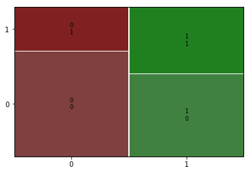

```python
# Let's plot the confusion matrix

## import necessary python library
from statsmodels.graphics.mosaicplot import mosaic

# plot the confusion matrix
mosaic(conf_matrix)
```

NOTE: Look at the dimensions of the confusion matrix:

- The width of each column is proportional to the fraction of observations in each category of actual values.
- each column displays the fraction of predicted observations with each value. </font>

### Model accuracy

*Accuracy* is the proportion of correct predictions.

$ accuracy = \frac{TN + TP}{TN + FN + FP + TP } $

```python
# let's retrieve the numbers manually
TN = conf_matrix[0,0]
TP = conf_matrix[1,1]
FN = conf_matrix[1,0]
FP = conf_matrix[0,1]

# compute "accuracy" manually
acc = (TN + TP) / (TN + TP + FN + FP)
print(acc)
```

```
0.575
```

Higher accuracy is better.

### Model sensitivity

*Sensitivity* is the proportion of true positives.

$ sensitivity = \frac{TP}{FN + TP} $

```python
# compute "sensitivity" manually
sens = (TP) / (FN + TP)
print(sens)
```

```
0.445
```

Higher sensitivity is better.

### Model specificity

*Specificity* is the proportion of true negatives.

$ specificity = \frac{TN}{TN + FP} $

```python
# compute "specificity" manually
spec = (TN) / (TN + FP)
print(spec)
```

```
0.705
```

Higher specificity is better, though there's often a trade-off where higher specificity will decrease sensitivity, or increasing sensitivity will decrease specificity.

### Confusion matrix quiz

[figure not shown]

The end! :)